# QMSS5074GR - Final Project (3rd)

## Part 5 – Transfer Learning & Advanced Architectures

### 5.1 Pre-trained Embeddings (GloVe)

- Retrain one network using pre-trained GloVe embeddings.
- Compare results against your from-scratch embedding runs.

```python
# Download GloVe embeddings (requires manual download or wget)
# Download from: https://nlp.stanford.edu/data/glove.6B.zip
# Extract glove.6B.100d.txt

import os

GLOVE_PATH = "glove.6B.100d.txt"

if not os.path.exists(GLOVE_PATH):
    print("GloVe file not found. Downloading...")
    import urllib.request
    import zipfile

    url = "https://nlp.stanford.edu/data/glove.6B.zip"
    zip_path = "glove.6B.zip"

    try:
        print("Downloading GloVe embeddings (this may take a few minutes)...")
        urllib.request.urlretrieve(url, zip_path)

        print("Extracting...")
        with zipfile.ZipFile(zip_path, 'r') as zip_ref:
            zip_ref.extractall(".")

        os.remove(zip_path)
        print("GloVe embeddings downloaded and extracted.")
    except Exception as e:
        print(f"Error downloading GloVe: {e}")
        print("Please download manually from https://nlp.stanford.edu/data/glove.6B.zip")

# Load GloVe embeddings
def load_glove_embeddings(glove_path, embedding_dim=100):
    """Load GloVe embeddings into a dictionary."""
    embeddings_index = {}

    with open(glove_path, 'r', encoding='utf-8') as f:
        for line in f:
            values = line.split()
            word = values[0]
            coefs = np.asarray(values[1:], dtype='float32')
            embeddings_index[word] = coefs

    print(f"Loaded {len(embeddings_index)} word vectors.")
    return embeddings_index

if os.path.exists(GLOVE_PATH):
    embeddings_index = load_glove_embeddings(GLOVE_PATH)

    # Create embedding matrix
    GLOVE_DIM = 100
    embedding_matrix = np.zeros((VOCAB_SIZE, GLOVE_DIM))

    for word, i in neural_tokenizer.word_index.items():
        if i >= VOCAB_SIZE:
            continue
        embedding_vector = embeddings_index.get(word)
        if embedding_vector is not None:
            embedding_matrix[i] = embedding_vector

    print(f"Created embedding matrix of shape: {embedding_matrix.shape}")
else:
    print("Skipping GloVe embeddings. File not available.")
    embedding_matrix = None
```

```
Loaded 400000 word vectors.
Created embedding matrix of shape: (13757, 100)
```

```python
import os

if embedding_matrix is not None:
    def build_cnn_with_glove(trainable=False):
        """Build CNN with pre-trained GloVe embeddings."""
        model = Sequential([
            Embedding(input_dim=VOCAB_SIZE,
                      output_dim=GLOVE_DIM,
                      input_length=MAX_LEN,
                      weights=[embedding_matrix],
                      trainable=trainable),
            Conv1D(filters=128, kernel_size=5, activation='relu'),
            GlobalMaxPooling1D(),
            Dense(128, activation='relu'),
            Dropout(0.5),
            Dense(64, activation='relu'),
            Dropout(0.3),
            Dense(1, activation='sigmoid')
        ])

        model.compile(optimizer='adam',
                      loss='binary_crossentropy',
                      metrics=['accuracy'])
        return model

    os.makedirs('models', exist_ok=True)

    # Train with frozen GloVe embeddings
    glove_frozen_path = 'models/cnn_glove_frozen.h5'
    if os.path.exists(glove_frozen_path):
        print("✓ Loading existing CNN with FROZEN GloVe embeddings...")
        cnn_glove_frozen = load_model(glove_frozen_path)
    else:
        print("Training CNN with FROZEN GloVe embeddings...")
        cnn_glove_frozen = build_cnn_with_glove(trainable=False)

        history_glove_frozen = cnn_glove_frozen.fit(
            X_train_padded, y_train,
            validation_data=(X_val_padded, y_val),
            epochs=20,
            batch_size=64,
            callbacks=[early_stop],
            verbose=1
        )

        cnn_glove_frozen.save(glove_frozen_path)
        print(f"✓ Model saved to {glove_frozen_path}")

    results_nn.append(evaluate_nn_model(cnn_glove_frozen, X_test_padded, y_test, "CNN + GloVe (Frozen)"))

    # Train with trainable GloVe embeddings
    glove_trainable_path = 'models/cnn_glove_trainable.h5'
    if os.path.exists(glove_trainable_path):
        print("\n✓ Loading existing CNN with TRAINABLE GloVe embeddings...")
        cnn_glove_trainable = load_model(glove_trainable_path)
    else:
        print("\nTraining CNN with TRAINABLE GloVe embeddings...")
        cnn_glove_trainable = build_cnn_with_glove(trainable=True)

        history_glove_trainable = cnn_glove_trainable.fit(
            X_train_padded, y_train,
            validation_data=(X_val_padded, y_val),
            epochs=20,
            batch_size=64,
            callbacks=[early_stop],
            verbose=1
        )

        cnn_glove_trainable.save(glove_trainable_path)
        print(f"✓ Model saved to {glove_trainable_path}")

    results_nn.append(evaluate_nn_model(cnn_glove_trainable, X_test_padded, y_test, "CNN + GloVe (Trainable)"))

    print("\nGloVe Embedding Comparison:")
    glove_results = pd.DataFrame(results_nn[-2:])
    print(glove_results.set_index("Model").round(4))
```

```
✓ Loading existing CNN with FROZEN GloVe embeddings...

✓ Loading existing CNN with TRAINABLE GloVe embeddings...

GloVe Embedding Comparison:
                         Accuracy  Precision  Recall      F1  ROC-AUC
Model
CNN + GloVe (Frozen)       0.7901     0.8129  0.7635  0.7875   0.8643
CNN + GloVe (Trainable)    0.8085     0.7721  0.8851  0.8248   0.9019
```

### 5.2 Transformer Fine-Tuning (BERT)

- Fine-tune a BERT-family model on the training data.
- Clearly outline your training hyperparameters.

```python
from transformers import BertTokenizer, TFBertForSequenceClassification
from transformers import DataCollatorWithPadding
import tensorflow as tf

# Load BERT tokenizer and model
model_name = "bert-base-uncased"
bert_tokenizer = BertTokenizer.from_pretrained(model_name)

# Tokenize datasets
def tokenize_data(sentences, max_length=128):
    """Tokenize sentences for BERT."""
    return bert_tokenizer(
        sentences.tolist(),
        max_length=max_length,
        padding='max_length',
        truncation=True,
        return_tensors='tf'
    )

train_encodings = tokenize_data(train_split["sentence"])
val_encodings = tokenize_data(val_split["sentence"])
test_encodings = tokenize_data(test_split["sentence"])

# Create TensorFlow datasets
train_dataset = tf.data.Dataset.from_tensor_slices((
    dict(train_encodings),
    y_train
)).batch(16)

val_dataset = tf.data.Dataset.from_tensor_slices((
    dict(val_encodings),
    y_val
)).batch(16)

test_dataset = tf.data.Dataset.from_tensor_slices((
    dict(test_encodings),
    y_test
)).batch(16)
```

```
TensorFlow and JAX classes are deprecated and will be removed in Transformers v5. We recommend migrating to PyTorch classes or pinning your version of Transformers.
```

```python
import os

# Create models directory
os.makedirs('models', exist_ok=True)

bert_model_path = 'models/bert_model'
if os.path.exists(bert_model_path):
    print("✓ Loading existing fine-tuned BERT model...")
    bert_model = TFBertForSequenceClassification.from_pretrained(bert_model_path)
else:
    # Load and configure BERT model
    bert_model = TFBertForSequenceClassification.from_pretrained(
        model_name,
        num_labels=2,
        from_pt=True,
        use_safetensors=False
    )

    # Training hyperparameters
    LEARNING_RATE = 2e-5
    BATCH_SIZE = 16
    EPOCHS = 3

    print("BERT Fine-tuning Hyperparameters:")
    print(f"  Model: {model_name}")
    print(f"  Learning Rate: {LEARNING_RATE}")
    print(f"  Batch Size: {BATCH_SIZE}")
    print(f"  Epochs: {EPOCHS}")
    print(f"  Optimizer: Adam")
    print(f"  Loss: Sparse Categorical Crossentropy")

    # Compile model
    optimizer = tf.keras.optimizers.legacy.Adam(learning_rate=LEARNING_RATE)

    bert_model.compile(
        optimizer=optimizer,
        loss=tf.keras.losses.SparseCategoricalCrossentropy(from_logits=True),
        metrics=["accuracy"]
    )

    # Train BERT
    print("\nFine-tuning BERT...")
    history_bert = bert_model.fit(
        train_dataset,
        validation_data=val_dataset,
        epochs=EPOCHS,
        verbose=1
    )

    # Save model
    bert_model.save_pretrained(bert_model_path)
    print(f"✓ Model saved to {bert_model_path}")
```

```
TensorFlow and JAX classes are deprecated and will be removed in Transformers v5. We recommend migrating to PyTorch classes or pinning your version of Transformers.
```

```
✓ Loading existing fine-tuned BERT model...
```

[output not shown]

```python
# Evaluate BERT
def evaluate_bert(model, test_dataset, y_true):
    """Evaluate BERT model."""
    predictions = model.predict(test_dataset, verbose=0)
    logits = predictions.logits
    y_pred = np.argmax(logits, axis=1)
    y_pred_prob = tf.nn.softmax(logits, axis=1).numpy()[:, 1]

    return {
        "Model": "BERT (Fine-tuned)",
        "Accuracy": accuracy_score(y_true, y_pred),
        "Precision": precision_score(y_true, y_pred),
        "Recall": recall_score(y_true, y_pred),
        "F1": f1_score(y_true, y_pred),
        "ROC-AUC": roc_auc_score(y_true, y_pred_prob)
    }

bert_results = evaluate_bert(bert_model, test_dataset, y_test)
results_nn.append(bert_results)

print("\nBERT Results:")
print(pd.DataFrame([bert_results]).set_index("Model").round(4))
```

```
BERT Results:
                   Accuracy  Precision  Recall      F1  ROC-AUC
Model
BERT (Fine-tuned)    0.8876     0.9651  0.8086  0.8799   0.9647
```

## Part 6 – Hyperparameter Optimization

### 6.1 Search Strategy with Optuna

- Use Optuna to optimize at least two hyperparameters.
- Describe search space and stopping criteria.

```python
import optuna
import numpy as np
import tensorflow as tf
import matplotlib.pyplot as plt

def build_model(trial):
    embedding_dim = trial.suggest_categorical("embedding_dim", [64, 128, 256])
    filters       = trial.suggest_categorical("filters", [64, 128, 256])
    kernel_size   = trial.suggest_categorical("kernel_size", [3, 4, 5])
    dense_units   = trial.suggest_categorical("dense_units", [64, 128, 256])
    dropout       = trial.suggest_float("dropout", 0.3, 0.7, step=0.2)
    lr            = trial.suggest_categorical("learning_rate", [1e-4, 1e-3, 1e-2])

    model = tf.keras.Sequential([
        tf.keras.layers.Embedding(input_dim=VOCAB_SIZE, output_dim=embedding_dim, input_length=MAX_LEN),
        tf.keras.layers.Conv1D(filters=filters, kernel_size=kernel_size, activation="relu"),
        tf.keras.layers.GlobalMaxPooling1D(),
        tf.keras.layers.Dense(dense_units, activation="relu"),
        tf.keras.layers.Dropout(dropout),
        tf.keras.layers.Dense(1, activation="sigmoid"),
    ])

    model.compile(
        optimizer=tf.keras.optimizers.Adam(learning_rate=lr),
        loss="binary_crossentropy",
        metrics=["accuracy"],
    )
    return model

def objective(trial):
    tf.keras.backend.clear_session()
    tf.random.set_seed(SEED)
    np.random.seed(SEED)

    model = build_model(trial)

    early_stop = tf.keras.callbacks.EarlyStopping(
        monitor="val_loss",
        patience=2,
        restore_best_weights=True
    )

    pruning_cb = optuna.integration.TFKerasPruningCallback(trial, monitor="val_loss")

    history = model.fit(
        X_train_padded, y_train,
        validation_data=(X_val_padded, y_val),
        epochs=10,
        batch_size=64,
        callbacks=[early_stop, pruning_cb],
        verbose=0
    )

    best_val_loss = float(np.min(history.history["val_loss"]))
    return best_val_loss

study = optuna.create_study(
    direction="minimize",
    sampler=optuna.samplers.TPESampler(seed=SEED),
    pruner=optuna.pruners.MedianPruner(n_startup_trials=5, n_warmup_steps=0)
)

study.optimize(objective, n_trials=20, timeout=None)

print("Best trial:")
print("  value (best val_loss):", study.best_value)
print("  params:", study.best_params)
```

```
[I 2025-12-15 22:07:11,715] A new study created in memory with name: no-name-139496cb-c698-48f7-b0c4-9587195027f5
2025-12-15 22:07:12.888761: I external/local_xla/xla/service/service.cc:163] XLA service 0x727f04b89c80 initialized for platform CUDA (this does not guarantee that XLA will be used). Devices:
2025-12-15 22:07:12.888783: I external/local_xla/xla/service/service.cc:171]   StreamExecutor device (0): NVIDIA GeForce RTX 4090, Compute Capability 8.9
2025-12-15 22:07:12.916219: I tensorflow/compiler/mlir/tensorflow/utils/dump_mlir_util.cc:269] disabling MLIR crash reproducer, set env var `MLIR_CRASH_REPRODUCER_DIRECTORY` to enable.
I0000 00:00:1765854433.013823  452930 device_compiler.h:196] Compiled cluster using XLA!  This line is logged at most once for the lifetime of the process.
[I 2025-12-15 22:07:43,218] Trial 0 finished with value: 0.22403354942798615 and parameters: {'embedding_dim': 128, 'filters': 64, 'kernel_size': 4, 'dense_units': 256, 'dropout': 0.7, 'learning_rate': 0.0001}. Best is trial 0 with value: 0.22403354942798615.
[I 2025-12-15 22:08:10,194] Trial 1 finished with value: 0.21451261639595032 and parameters: {'embedding_dim': 128, 'filters': 128, 'kernel_size': 5, 'dense_units': 64, 'dropout': 0.5, 'learning_rate': 0.001}. Best is trial 1 with value: 0.21451261639595032.
[I 2025-12-15 22:08:40,423] Trial 2 finished with value: 0.21763145923614502 and parameters: {'embedding_dim': 256, 'filters': 64, 'kernel_size': 3, 'dense_units': 256, 'dropout': 0.3, 'learning_rate': 0.0001}. Best is trial 1 with value: 0.21451261639595032.
[I 2025-12-15 22:09:07,152] Trial 3 finished with value: 0.21636827290058136 and parameters: {'embedding_dim': 256, 'filters': 128, 'kernel_size': 4, 'dense_units': 256, 'dropout': 0.5, 'learning_rate': 0.001}. Best is trial 1 with value: 0.21451261639595032.
[I 2025-12-15 22:09:34,046] Trial 4 finished with value: 0.21630939841270447 and parameters: {'embedding_dim': 128, 'filters': 256, 'kernel_size': 3, 'dense_units': 64, 'dropout': 0.7, 'learning_rate': 0.001}. Best is trial 1 with value: 0.21451261639595032.
[I 2025-12-15 22:09:52,465] Trial 5 pruned. Trial was pruned at epoch 1.
[I 2025-12-15 22:10:19,317] Trial 6 finished with value: 0.21501561999320984 and parameters: {'embedding_dim': 64, 'filters': 256, 'kernel_size': 5, 'dense_units': 256, 'dropout': 0.3, 'learning_rate': 0.001}. Best is trial 1 with value: 0.21451261639595032.
[I 2025-12-15 22:10:32,900] Trial 7 pruned. Trial was pruned at epoch 0.
[I 2025-12-15 22:10:46,405] Trial 8 pruned. Trial was pruned at epoch 0.
[I 2025-12-15 22:11:00,212] Trial 9 pruned. Trial was pruned at epoch 0.
[I 2025-12-15 22:11:13,723] Trial 10 pruned. Trial was pruned at epoch 0.
[I 2025-12-15 22:11:40,332] Trial 11 finished with value: 0.2106522172689438 and parameters: {'embedding_dim': 64, 'filters': 128, 'kernel_size': 5, 'dense_units': 128, 'dropout': 0.3, 'learning_rate': 0.001}. Best is trial 11 with value: 0.2106522172689438.
[I 2025-12-15 22:12:06,784] Trial 12 finished with value: 0.21276378631591797 and parameters: {'embedding_dim': 64, 'filters': 128, 'kernel_size': 5, 'dense_units': 128, 'dropout': 0.5, 'learning_rate': 0.001}. Best is trial 11 with value: 0.2106522172689438.
[I 2025-12-15 22:12:33,405] Trial 13 finished with value: 0.2115197628736496 and parameters: {'embedding_dim': 64, 'filters': 128, 'kernel_size': 5, 'dense_units': 128, 'dropout': 0.5, 'learning_rate': 0.001}. Best is trial 11 with value: 0.2106522172689438.
[I 2025-12-15 22:12:59,941] Trial 14 finished with value: 0.21282577514648438 and parameters: {'embedding_dim': 64, 'filters': 128, 'kernel_size': 5, 'dense_units': 128, 'dropout': 0.3, 'learning_rate': 0.001}. Best is trial 11 with value: 0.2106522172689438.
[I 2025-12-15 22:13:13,549] Trial 15 pruned. Trial was pruned at epoch 0.
[I 2025-12-15 22:13:26,989] Trial 16 pruned. Trial was pruned at epoch 0.
[I 2025-12-15 22:13:40,995] Trial 17 pruned. Trial was pruned at epoch 0.
[I 2025-12-15 22:13:54,487] Trial 18 pruned. Trial was pruned at epoch 0.
[I 2025-12-15 22:14:08,760] Trial 19 pruned. Trial was pruned at epoch 0.
```

```
Best trial:
  value (best val_loss): 0.2106522172689438
  params: {'embedding_dim': 64, 'filters': 128, 'kernel_size': 5, 'dense_units': 128, 'dropout': 0.3, 'learning_rate': 0.001}
```

### 6.2 Results Analysis

- Report best hyperparameter configuration.
- Plot validation metrics vs. trials.

Best trial: value (best val_loss): 0.2106522172689438 params: {'embedding_dim': 64, 'filters': 128, 'kernel_size': 5, 'dense_units': 128, 'dropout': 0.3, 'learning_rate': 0.001}

[figure not shown]

```python
vals = []
for t in study.trials:
    vals.append(t.value if t.value is not None else np.nan)

plt.figure(figsize=(8, 4))
plt.plot(vals, marker="o")
plt.xlabel("Trial")
plt.ylabel("Best Validation Loss")
plt.title("Optuna Hyperparameter Tuning: Val Loss vs Trials")
plt.grid(True)
plt.show()
```

## Part 7 – Final Comparison & Error Analysis

### 7.1 Consolidated Results

- Tabulate test-set performance for ALL models.
- Highlight top-performing model overall and top in each category.

```python
# Combine all results
all_results = results_traditional + results_nn
final_results_df = pd.DataFrame(all_results).set_index("Model")

print("\n" + "="*100)
print("FINAL MODEL COMPARISON - TEST SET PERFORMANCE")
print("="*100)
print(final_results_df.round(4))
print("="*100)

# Highlight best models
best_overall = final_results_df['F1'].idxmax()
best_f1 = final_results_df['F1'].max()

print(f"\nBEST OVERALL MODEL: {best_overall}")
print(f"   F1-Score: {best_f1:.4f}")
print(f"   Accuracy: {final_results_df.loc[best_overall, 'Accuracy']:.4f}")
print(f"   ROC-AUC: {final_results_df.loc[best_overall, 'ROC-AUC']:.4f}")

# Best in each category
traditional_models = ["Logistic Regression", "Linear SVM", "Random Forest", "Gradient Boosting"]
traditional_results = final_results_df.loc[[m for m in traditional_models if m in final_results_df.index]]
best_traditional = traditional_results['F1'].idxmax()

print(f"\nBEST TRADITIONAL MODEL: {best_traditional}")
print(f"   F1-Score: {traditional_results.loc[best_traditional, 'F1']:.4f}")

neural_results = final_results_df.drop(traditional_models, errors='ignore')
best_neural = neural_results['F1'].idxmax()

print(f"\nBEST NEURAL MODEL: {best_neural}")
print(f"   F1-Score: {neural_results.loc[best_neural, 'F1']:.4f}")
```

```
====================================================================================================
FINAL MODEL COMPARISON - TEST SET PERFORMANCE
====================================================================================================
                            Accuracy  Precision  Recall      F1  ROC-AUC
Model
Logistic Regression           0.8188     0.8043  0.8514  0.8271   0.8918
Linear SVM                    0.8245     0.8129  0.8514  0.8317   0.8877
Random Forest                 0.7557     0.7463  0.7883  0.7667   0.8502
Gradient Boosting             0.7099     0.6678  0.8559  0.7502   0.8168
MLP (Trainable Embeddings)    0.8028     0.7969  0.8221  0.8093   0.8805
MLP (Frozen Embeddings)       0.5092     0.5092  1.0000  0.6748   0.5000
1D-CNN                        0.8234     0.7971  0.8761  0.8348   0.9142
LSTM                          0.5092     0.5092  1.0000  0.6748   0.4868
Bi-LSTM                       0.8119     0.7778  0.8829  0.8270   0.8971
CNN + GloVe (Frozen)          0.7901     0.8129  0.7635  0.7875   0.8643
CNN + GloVe (Trainable)       0.8085     0.7721  0.8851  0.8248   0.9019
BERT (Fine-tuned)             0.8876     0.9651  0.8086  0.8799   0.9647
====================================================================================================

BEST OVERALL MODEL: BERT (Fine-tuned)
   F1-Score: 0.8799
   Accuracy: 0.8876
   ROC-AUC: 0.9647

BEST TRADITIONAL MODEL: Linear SVM
   F1-Score: 0.8317

BEST NEURAL MODEL: BERT (Fine-tuned)
   F1-Score: 0.8799
```

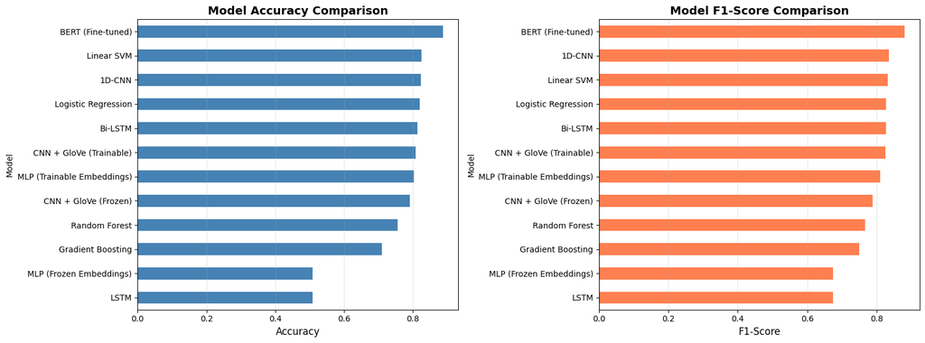

```python
# Visualize results
fig, axes = plt.subplots(1, 2, figsize=(16, 6))

# Accuracy comparison
final_results_df['Accuracy'].sort_values().plot(kind='barh', ax=axes[0], color='steelblue')
axes[0].set_title('Model Accuracy Comparison', fontsize=14, fontweight='bold')
axes[0].set_xlabel('Accuracy', fontsize=12)
axes[0].grid(axis='x', alpha=0.3)

# F1-Score comparison
final_results_df['F1'].sort_values().plot(kind='barh', ax=axes[1], color='coral')
axes[1].set_title('Model F1-Score Comparison', fontsize=14, fontweight='bold')
axes[1].set_xlabel('F1-Score', fontsize=12)
axes[1].grid(axis='x', alpha=0.3)

plt.tight_layout()
plt.show()
```

### 7.2 Statistical Significance (McNemar's Test)

- Perform significance test between top two models.

```python
import numpy as np
import pandas as pd
from statsmodels.stats.contingency_tables import mcnemar

# ---------- Model 1 predictions (traditional) ----------
model1_name = best_traditional
if model1_name == "Logistic Regression":
    y_pred_model1 = final_logreg.predict(X_test_tfidf)
elif model1_name == "Linear SVM":
    y_pred_model1 = final_svm.predict(X_test_tfidf)
elif model1_name == "Random Forest":
    y_pred_model1 = rf.predict(X_test_tfidf)
else:
    y_pred_model1 = gb.predict(X_test_tfidf)

y_pred_model1 = np.asarray(y_pred_model1).astype(int)

# ---------- Model 2 predictions (BERT) ----------
model2_name = best_neural

# For TFBertForSequenceClassification: predict() usually returns logits (N, 2)
logits = bert_model.predict(X_test_padded, verbose=0).logits  # safer than flatten()
y_pred_model2 = np.argmax(logits, axis=1).astype(int)

# ---------- Correctness vectors ----------
y_test_arr = np.asarray(y_test).astype(int)

m1_correct = (y_pred_model1 == y_test_arr)
m2_correct = (y_pred_model2 == y_test_arr)

# Build 2x2 table on correctness:
# rows = model1 (correct/ wrong), cols = model2 (correct/ wrong)
n11 = np.sum(m1_correct & m2_correct)      # both correct
n10 = np.sum(m1_correct & ~m2_correct)     # model1 correct, model2 wrong  (b)
n01 = np.sum(~m1_correct & m2_correct)     # model1 wrong, model2 correct  (c)
n00 = np.sum(~m1_correct & ~m2_correct)    # both wrong

table = np.array([[n11, n10],
                  [n01, n00]])

print("\n" + "="*80)
print(f"McNemar's Test: {model1_name} vs {model2_name}")
print("="*80)
print(pd.DataFrame(
    table,
    index=[f"{model1_name} Correct", f"{model1_name} Wrong"],
    columns=[f"{model2_name} Correct", f"{model2_name} Wrong"]
))

b, c = n10, n01
print(f"\nDiscordant pairs: b (M1 correct, M2 wrong) = {b}, c (M1 wrong, M2 correct) = {c}")

# exact is fine for small b+c, but can be slow if huge
use_exact = (b + c) <= 2000  # heuristic; adjust if needed
result = mcnemar(table, exact=use_exact, correction=not use_exact)

print(f"\nMcNemar Statistic: {result.statistic:.4f}")
print(f"P-value: {result.pvalue:.6f}")

alpha = 0.05
if result.pvalue < alpha:
    print(f"\nResult: STATISTICALLY SIGNIFICANT difference (p < {alpha}).")
else:
    print(f"\nResult: NO statistically significant difference (p >= {alpha}).")
print("="*80)
```

```
================================================================================
McNemar's Test: Linear SVM vs BERT (Fine-tuned)
================================================================================
                    BERT (Fine-tuned) Correct  BERT (Fine-tuned) Wrong
Linear SVM Correct                        343                      376
Linear SVM Wrong                           87                       66

Discordant pairs: b (M1 correct, M2 wrong) = 376, c (M1 wrong, M2 correct) = 87

McNemar Statistic: 87.0000
P-value: 0.000000

Result: STATISTICALLY SIGNIFICANT difference (p < 0.05).
================================================================================
```

### 7.3 Error Analysis

- Identify at least 20 misclassified examples.
- Analyze 5 examples in detail.

```python
import numpy as np
import pandas as pd
import tensorflow as tf

# Predict
pred_out = bert_model.predict(X_test_padded, verbose=0)

# logits: shape (N, 2) for num_labels=2
logits = pred_out.logits if hasattr(pred_out, "logits") else pred_out

# Convert to probabilities for positive class
probs = tf.nn.softmax(logits, axis=1).numpy()   # (N,2)
y_prob_pos = probs[:, 1]                        # positive prob
y_pred_best = (y_prob_pos >= 0.5).astype(int)   # predicted label

misclassified_idx = np.where(y_pred_best != y_test)[0]

print(f"Total misclassified examples: {len(misclassified_idx)}")
print(f"Accuracy: {(1 - len(misclassified_idx)/len(y_test))*100:.2f}%\n")
```

[output not shown]

```python
import numpy as np
import tensorflow as tf

# Get logits from BERT
pred_out = bert_model.predict(X_test_padded, verbose=0)
logits = pred_out.logits if hasattr(pred_out, "logits") else pred_out

# Convert to probabilities and labels
probs = tf.nn.softmax(logits, axis=1).numpy()
y_prob_pos = probs[:, 1]
y_pred = (y_prob_pos >= 0.5).astype(int)
```

```python
mis_idx = np.where(y_pred != y_test)[0]

print(f"Total misclassified examples: {len(mis_idx)}")
assert len(mis_idx) >= 20, "Fewer than 20 misclassified examples"
```

```
Total misclassified examples: 442
```

```python
# Model confidence
confidence = np.maximum(y_prob_pos, 1 - y_prob_pos)

# Sort misclassified by confidence (descending)
hard_errors = mis_idx[np.argsort(-confidence[mis_idx])]

selected_idx = hard_errors[:20]
```

```python
import pandas as pd

error_rows = []
for idx in selected_idx:
    error_rows.append({
        "Index": int(idx),
        "Raw Text": test_split.iloc[idx]["sentence"],
        "True Label": "Positive" if y_test[idx] == 1 else "Negative",
        "Predicted Label": "Positive" if y_pred[idx] == 1 else "Negative",
        "P(Positive)": float(y_prob_pos[idx]),
        "Confidence": float(max(y_prob_pos[idx], 1 - y_prob_pos[idx]))
    })

errors_df = pd.DataFrame(error_rows)
errors_df
```

|  | Index | Raw Text | True Label | Predicted Label | P(Positive) | Confidence |
| --- | --- | --- | --- | --- | --- | --- |
| 0 | 806 | griffiths proves she 's that rare luminary who... | Positive | Negative | 0.002220 | 0.997779 |
| 1 | 249 | huston nails both the glad-handing and the cho... | Positive | Negative | 0.002918 | 0.997082 |
| 2 | 467 | ramsay , as in ratcatcher , remains a filmmake... | Positive | Negative | 0.009317 | 0.990683 |
| 3 | 404 | zhang ... has done an amazing job of getting r... | Positive | Negative | 0.010834 | 0.989166 |
| 4 | 366 | altogether , this is successful as a film , wh... | Positive | Negative | 0.011817 | 0.988183 |
| 5 | 458 | featuring a dangerously seductive performance ... | Positive | Negative | 0.013047 | 0.986953 |
| 6 | 117 | moody , heartbreaking , and filmed in a natura... | Positive | Negative | 0.013357 | 0.986643 |
| 7 | 524 | the fly-on-the-wall method used to document ru... | Positive | Negative | 0.014991 | 0.985009 |
| 8 | 498 | anchored by friel and williams 's exceptional ... | Positive | Negative | 0.015498 | 0.984502 |
| 9 | 634 | harris commands the screen , using his frailty... | Positive | Negative | 0.015539 | 0.984461 |
| 10 | 475 | belongs to daniel day-lewis as much as it belo... | Positive | Negative | 0.017188 | 0.982812 |
| 11 | 511 | lapaglia 's ability to convey grief and hope w... | Positive | Negative | 0.018765 | 0.981235 |
| 12 | 24 | seldom has a movie so closely matched the spir... | Positive | Negative | 0.019493 | 0.980507 |
| 13 | 865 | mcconaughey 's fun to watch , the dragons are ... | Positive | Negative | 0.019568 | 0.980432 |
| 14 | 808 | enormously entertaining for moviegoers of any ... | Positive | Negative | 0.019776 | 0.980224 |
| 15 | 691 | an effectively creepy , fear-inducing ( not fe... | Positive | Negative | 0.019786 | 0.980214 |
| 16 | 270 | dense with characters and contains some thrill... | Positive | Negative | 0.019978 | 0.980022 |
| 17 | 17 | audrey tatou has a knack for picking roles tha... | Positive | Negative | 0.020256 | 0.979744 |
| 18 | 186 | pacino is brilliant as the sleep-deprived dorm... | Positive | Negative | 0.023131 | 0.976869 |
| 19 | 332 | broomfield turns his distinctive ` blundering ... | Positive | Negative | 0.023569 | 0.976431 |

```python
errors_df_5 = errors_df[:5]

raw_texts_5 = errors_df_5["Raw Text"]
```

```python
print("Raw: ", raw_texts_5[0])
print("Predicted Label: Negative")
"""Models may struggle to recognize positive sentiment when it is expressed through abstract, formal praise rather than explicit sentiment-bearing words."""
```

```
Raw:  griffiths proves she 's that rare luminary who continually raises the standard of her profession .
Predicted Label: Negative
```

```
'Models may struggle to recognize positive sentiment when it is expressed through abstract, formal praise rather than explicit sentiment-bearing words.'
```

```python
print("Raw: ", raw_texts_5[1])
print("Predicted Label: Negative")
"""model struggles to separate sentiment toward the subject matter from sentiment toward the work itself, especially when negative emotions are portrayed as evidence of artistic effectiveness."""
```

```
Raw:  huston nails both the glad-handing and the choking sense of hollow despair .
Predicted Label: Negative
```

```
'model struggles to separate sentiment toward the subject matter from sentiment toward the work itself, especially when negative emotions are portrayed as evidence of artistic effectiveness.'
```

```python
print("Raw: ", raw_texts_5[2])
print("Predicted Label: Negative")
"""the classifier may conflate sentiment toward the emotional tone of a film’s content with sentiment toward the filmmaker’s competence."""
```

```
Raw:  ramsay , as in ratcatcher , remains a filmmaker with an acid viewpoint and a real gift for teasing chilly poetry out of lives and settings that might otherwise seem drab and sordid .
Predicted Label: Negative
```

```
'the classifier may conflate sentiment toward the emotional tone of a film’s content with sentiment toward the filmmaker’s competence.'
```

```python
print("Raw: ", raw_texts_5[3])
print("Predicted Label: Negative")
"""Models may under-recognize positive sentiment when praise is expressed through professional or technical evaluation rather than emotional adjectives."""
```

```
Raw:  zhang ... has done an amazing job of getting realistic performances from his mainly nonprofessional cast .
Predicted Label: Negative
```

```
'Models may under-recognize positive sentiment when praise is expressed through professional or technical evaluation rather than emotional adjectives.'
```

```python
print("Raw: ", raw_texts_5[4])
print("Predicted Label: Negative")
"""model may fail to fully capture this form of balanced, critical endorsement, particularly when positive sentiment is expressed through abstract judgments (e.g., “reconsideration”) rather than explicit affective language."""
```

```
Raw:  altogether , this is successful as a film , while at the same time being a most touching reconsideration of the familiar masterpiece .
Predicted Label: Negative
```

```
'model may fail to fully capture this form of balanced, critical endorsement, particularly when positive sentiment is expressed through abstract judgments (e.g., “reconsideration”) rather than explicit affective language.'
```

## Part 8 – Optional Challenge Extensions (BONUS)

### 8.1 Data Augmentation

- Implement synonym swapping for text augmentation.
- Measure its impact on model performance.

```python
import nltk
nltk.download('wordnet')
nltk.download('omw-1.4')
nltk.download('averaged_perceptron_tagger')
```

```
True
```

```python
# Install nlpaug if not available
# !pip install -q nlpaug

import nlpaug.augmenter.word as naw
from nltk.corpus import wordnet
import nlpaug.model.word_dict.wordnet as nmw
nmw.wordnet = wordnet
# Synonym augmenter
aug = naw.SynonymAug(
    aug_src='wordnet'
)

def augment_text(text, num_aug=1):
    """Augment text using synonym replacement."""
    try:
        augmented = aug.augment(text, n=num_aug)
        return augmented if isinstance(augmented, list) else [augmented]
    except:
        return [text]

# Augment training data (only negative class for balance)
print("Augmenting training data...")
augmented_data = []

# Augment only a subset for demonstration (e.g., 1000 samples)
neg_samples = train_split[train_split['label'] == 0].head(1000)

for _, row in neg_samples.iterrows():
    aug_text = augment_text(row['sentence'])[0]
    augmented_data.append({
        'sentence': aug_text,
        'label': row['label'],
        'cleaned_sentence': clean_text(aug_text)
    })

augmented_df = pd.DataFrame(augmented_data)
train_augmented = pd.concat([train_split, augmented_df], ignore_index=True)

print(f"Original training size: {len(train_split)}")
print(f"Augmented training size: {len(train_augmented)}")
print(f"\nExample augmentation:")
print(f"Original: {neg_samples.iloc[0]['sentence']}")
print(f"Augmented: {augmented_data[0]['sentence']}")
```

```
Augmenting training data...
Original training size: 60614
Augmented training size: 61614

Example augmentation:
Original: barely makes sense , with its unbelievable naïveté and arbitrary flashbacks .
Augmented: barely makes sense , with its unbelievable naïveté and arbitrary flashbacks .
```

```python
# Train model with augmented data
print("\nTraining CNN with augmented data...")

# Prepare augmented sequences
X_train_aug_seq = neural_tokenizer.texts_to_sequences(train_augmented['cleaned_sentence'])
X_train_aug_padded = pad_sequences(X_train_aug_seq, maxlen=MAX_LEN, padding='post', truncating='post')
y_train_aug = train_augmented['label'].values

# Build and train model
cnn_augmented = build_cnn()
history_aug = cnn_augmented.fit(
    X_train_aug_padded, y_train_aug,
    validation_data=(X_val_padded, y_val),
    epochs=15,
    batch_size=64,
    callbacks=[early_stop],
    verbose=1
)

# Evaluate
aug_results = evaluate_nn_model(cnn_augmented, X_test_padded, y_test, "CNN (With Data Augmentation)")

print("\nData Augmentation Impact:")
comparison_df = pd.DataFrame([
    evaluate_nn_model(cnn_model, X_test_padded, y_test, "CNN (No Augmentation)"),
    aug_results
]).set_index('Model')
print(comparison_df.round(4))
```

```
Training CNN with augmented data...

Data Augmentation Impact:
                              Accuracy  Precision  Recall      F1  ROC-AUC
Model
CNN (No Augmentation)           0.8234     0.7971  0.8761  0.8348   0.9142
CNN (With Data Augmentation)    0.8177     0.8291  0.8086  0.8187   0.9066
```

### 8.2 Sentiment Lexicon Integration (VADER)

- Add VADER sentiment scores as features.
- Assess improvement in predictions.

```python
# Install vaderSentiment
# !pip install -q vaderSentiment

from vaderSentiment.vaderSentiment import SentimentIntensityAnalyzer

analyzer = SentimentIntensityAnalyzer()

def get_vader_scores(text):
    """Get VADER sentiment scores."""
    scores = analyzer.polarity_scores(text)
    return [scores['neg'], scores['neu'], scores['pos'], scores['compound']]

# Add VADER features
print("Computing VADER scores...")
train_vader = np.array([get_vader_scores(text) for text in train_split['sentence']])
val_vader = np.array([get_vader_scores(text) for text in val_split['sentence']])
test_vader = np.array([get_vader_scores(text) for text in test_split['sentence']])

print(f"VADER features shape: {train_vader.shape}")
print(f"\nExample VADER scores (first review):")
print(f"Text: {train_split.iloc[0]['sentence']}")
print(f"Scores: neg={train_vader[0][0]:.3f}, neu={train_vader[0][1]:.3f}, "
      f"pos={train_vader[0][2]:.3f}, compound={train_vader[0][3]:.3f}")
```

```
Computing VADER scores...
VADER features shape: (60614, 4)

Example VADER scores (first review):
Text: emphasis
Scores: neg=0.000, neu=1.000, pos=0.000, compound=0.000
```

```python
from scipy.sparse import hstack

# Combine TF-IDF with VADER features
X_train_combined = hstack([X_train_tfidf, train_vader])
X_val_combined = hstack([X_val_tfidf, val_vader])
X_test_combined = hstack([X_test_tfidf, test_vader])

print(f"Combined features shape: {X_train_combined.shape}")

# Train logistic regression with combined features
print("\nTraining Logistic Regression with VADER features...")
lr_vader = LogisticRegression(C=best_lr_C, max_iter=1000, solver='liblinear', random_state=SEED)
lr_vader.fit(X_train_combined, y_train)

vader_results = compute_metrics(lr_vader, X_test_combined, y_test, "LR + VADER")

print("\nVADER Feature Impact:")
vader_comparison = pd.DataFrame([
    compute_metrics(final_logreg, X_test_tfidf, y_test, "LR (TF-IDF only)"),
    vader_results
]).set_index('Model')
print(vader_comparison.round(4))
```

```
Combined features shape: (60614, 5004)

Training Logistic Regression with VADER features...

VADER Feature Impact:
                  Accuracy  Precision  Recall      F1  ROC-AUC
Model
LR (TF-IDF only)    0.8188     0.8043  0.8514  0.8271   0.8918
LR + VADER          0.8200     0.8047  0.8536  0.8284   0.9023
```

### 8.3 Model Deployment (Simple REST API)

- Deploy best model as a Flask API.
- Demo on user-submitted reviews.

```python
import os
save_dir = "best_bert_sentiment"
os.makedirs(save_dir, exist_ok=True)

bert_model.save_pretrained(save_dir)
bert_tokenizer.save_pretrained(save_dir)
print(f"✓ Best model saved to {save_dir} (Hugging Face format)")

# Create a simple Flask API
flask_api_code = '''
from flask import Flask, request, jsonify
import tensorflow as tf
from tensorflow.keras.preprocessing.sequence import pad_sequences
import joblib
import numpy as np

app = Flask(__name__)

# Load model and tokenizer
model = tf.keras.models.load_model('best_sentiment_model.h5')
tokenizer = joblib.load('neural_tokenizer.joblib')
MAX_LEN = 100

@app.route('/predict', methods=['POST'])
def predict():
    data = request.get_json()
    text = data.get('text', '')

    # Preprocess
    seq = tokenizer.texts_to_sequences([text])
    padded = pad_sequences(seq, maxlen=MAX_LEN, padding='post', truncating='post')

    # Predict
    pred_prob = model.predict(padded, verbose=0)[0][0]
    sentiment = 'Positive' if pred_prob > 0.5 else 'Negative'

    return jsonify({
        'text': text,
        'sentiment': sentiment,
        'confidence': float(pred_prob)
    })

@app.route('/health', methods=['GET'])
def health():
    return jsonify({'status': 'healthy'})

if __name__ == '__main__':
    app.run(host='0.0.0.0', port=5000, debug=True)
'''

# Save Flask API code
with open('sentiment_api.py', 'w') as f:
    f.write(flask_api_code)

print("✓ Flask API code saved to sentiment_api.py")
print("\nTo run the API:")
print("  python sentiment_api.py")
print("\nTo test:")
print("  curl -X POST http://localhost:5000/predict -H 'Content-Type: application/json' -d '{\"text\":\"This movie was amazing!\"}'")
```

```
✓ Best model saved to best_bert_sentiment (Hugging Face format)
✓ Flask API code saved to sentiment_api.py

To run the API:
  python sentiment_api.py

To test:
  curl -X POST http://localhost:5000/predict -H 'Content-Type: application/json' -d '{"text":"This movie was amazing!"}'
```

```python
import tensorflow as tf
import numpy as np

def predict_sentiment(text):
    """Predict sentiment for a given text using BERT."""

    inputs = bert_tokenizer(
        text,
        return_tensors="tf",
        truncation=True,
        padding=True,
        max_length=128
    )

    outputs = bert_model(**inputs)

    logits = outputs.logits            # shape (1, 2)
    probs = tf.nn.softmax(logits, axis=1).numpy()[0]

    pred_label = int(np.argmax(probs))
    sentiment = "Positive" if pred_label == 1 else "Negative"
    confidence = float(probs[pred_label])

    return {
        "text": text,
        "sentiment": sentiment,
        "confidence": confidence
    }

demo_reviews = [
    "This movie was absolutely fantastic! I loved every minute of it.",
    "Worst film I've ever seen. Complete waste of time.",
    "It was okay, nothing special but not terrible either.",
    "The acting was superb and the cinematography was breathtaking.",
    "Boring and predictable. Would not recommend."
]

print("\n" + "="*100)
print("DEMO: Sentiment Predictions on User Reviews")
print("="*100)

for i, review in enumerate(demo_reviews, 1):
    result = predict_sentiment(review)
    print(f"\n[{i}] {result['text']}")
    print(f"    → Sentiment: {result['sentiment']} (Confidence: {result['confidence']:.4f})")

print("\n" + "="*100)
```

```
====================================================================================================
DEMO: Sentiment Predictions on User Reviews
====================================================================================================

[1] This movie was absolutely fantastic! I loved every minute of it.
    → Sentiment: Positive (Confidence: 0.9998)

[2] Worst film I've ever seen. Complete waste of time.
    → Sentiment: Negative (Confidence: 0.9997)

[3] It was okay, nothing special but not terrible either.
    → Sentiment: Positive (Confidence: 0.7651)
```

```
[4] The acting was superb and the cinematography was breathtaking.
    → Sentiment: Positive (Confidence: 0.9998)

[5] Boring and predictable. Would not recommend.
    → Sentiment: Negative (Confidence: 0.9997)

====================================================================================================
```

# Reflecting

**Answer the following inference questions:**

### Part 1 – Data Ingestion & Preprocessing

1. **Data Loading**
   - How do you ensure that your dataset is properly split into training, validation, and test sets, and why is class balance important during data splitting?

   **Answer：**

We ensure a proper data split by dividing the dataset into training, validation, and test sets, with the training set used for model fitting and cross-validation, and the test set held out for final evaluation.

Stratified sampling is applied during splitting to preserve the original class distribution across all subsets. Maintaining class balance is important because imbalanced splits can bias the model toward the majority class, leading to misleading performance metrics and poor generalization. In this dataset, the class distribution is approximately balanced, which reduces the risk of biased learning and allows standard evaluation metrics such as accuracy to remain meaningful.

2. **Text Cleaning & Tokenization**
   - What is the role of tokenization in text preprocessing, and how does it impact the model's performance?

   **Answer：**

Tokenization converts raw text into discrete units (tokens), such as words, which serve as the basic features for text models. Combined with text cleaning steps like lowercasing and punctuation removal, tokenization standardizes the input and reduces noise. This process directly impacts model performance by determining the feature space on which models are trained.

Effective tokenization allows models to capture sentiment-relevant lexical patterns while reducing sparsity and dimensionality issues, thereby improving both efficiency and predictive accuracy.

### Part 2 – Exploratory Data Analysis (EDA)

1. **Class Distribution**
   - How does the class distribution (positive vs negative reviews) impact the model’s performance, and what strategies can be used if the dataset is imbalanced?

   **Answer：**

The dataset had a nearly balanced distribution. This balance helps prevent the model from favoring one class over the other and supports stable training and evaluation. If the dataset were imbalanced, strategies such as class weighting, resampling (over-sampling or under-sampling), or alternative evaluation metrics (e.g., F1-score or ROC-AUC) would be necessary. In this case, no additional imbalance-handling techniques are required.

2. **Text Characteristics**
   - What insights can be gained from visualizing word clouds for each sentiment class, and how can it improve feature engineering?

   **Answer：**

Word clouds and token frequency plots reveal sentiment-specific vocabulary patterns. Negative reviews prominently feature words such as bad, worst, and boring, while positive reviews emphasize words like great, funny, and best. These visualizations confirm that sentiment is strongly reflected in word choice, supporting the use of bag-of-words and TF-IDF features. Such insights can guide feature engineering decisions, including n-gram selection, stop-word handling, and the inclusion of sentiment-bearing tokens.

### Part 3 – Baseline Traditional Models

1. **Logistic Regression & SVM**
   - Why do you use cross-validation when training models like logistic regression or SVM, and how does it help prevent overfitting?

   **Answer：**

Cross-validation is used to evaluate model performance across multiple data splits, providing a more reliable estimate of generalization performance. By tuning hyperparameters such as the regularization strength 𝐶 using 5-fold cross-validation, the model avoids overfitting to a single training split. This process balances bias and variance, ensuring that the selected hyperparameters generalize well to unseen data.

2. **Random Forest & Gradient Boosting**
   - What role does feature importance play in interpreting Random Forest or XGBoost models?

   **Answer：**

Feature importance quantifies the contribution of individual tokens to the model’s predictions, offering interpretability for otherwise complex models. In this analysis, tree-based models identify sentiment-bearing words such as good, bad, funny, and best as highly influential features. These results align with earlier EDA findings and provide insight into how non-linear models utilize lexical cues to make predictions.

### Part 4 – Neural Network Models

1. **Simple Feed-Forward**
   - Why is embedding freezing used when training neural networks on pre-trained embeddings, and how does it affect model performance?

   **Answer：**

Embedding freezing is used to preserve the semantic knowledge already encoded in pre-trained embeddings such as GloVe, which are trained on very large corpora. By freezing the embedding layer, the model avoids overfitting to a relatively small labeled dataset like SST-2 and reduces the number of trainable parameters.

2. **Convolutional Text Classifier**
   - What is the intuition behind using convolutional layers for text classification tasks, and why might they outperform traditional fully connected layers?

   **Answer：**

Convolutional layers capture local n-gram patterns in text by applying sliding filters over sequences of word embeddings. Each filter acts as a detector for informative phrases such as *“not good”*, *“very funny”*, or *“highly disappointing”*, regardless of their position in the sentence.

Compared to fully connected layers, CNNs are more parameter-efficient, preserve local word order, and introduce translation invariance. This allows CNNs to outperform simple MLPs in text classification by focusing on meaningful local features rather than treating the entire sentence as an unordered vector.

### Part 5 – Transfer Learning & Advanced Architectures

1. **Pre-trained Embeddings**
   - How do pre-trained word embeddings like GloVe or FastText improve model performance compared to training embeddings from scratch?

   **Answer：**

Pre-trained embeddings encode semantic and syntactic relationships learned from massive unlabeled corpora, allowing models to start from a linguistically meaningful representation space. In contrast, embeddings trained from scratch rely solely on the limited labeled dataset and may fail to learn robust word representations.

2. **Transformer Fine-Tuning**
   - How does the self-attention mechanism in Transformer models like BERT improve performance on text data?

   **Answer：**

Self-attention allows each token to attend to every other token in the sequence, enabling the model to capture long-range dependencies and contextual meaning dynamically. Unlike bag-of-words or CNN models, Transformers do not rely on fixed context windows.

In BERT, bidirectional self-attention ensures that each word representation incorporates information from both left and right context, which is particularly beneficial for sentiment tasks involving negation or contrast. This capability explains why BERT fine-tuning outperforms traditional and shallow neural models in our comparison.

### Part 6 – Hyperparameter Optimization

1. **Search Strategy**
   - How does hyperparameter optimization help improve the model’s performance, and what challenges arise when selecting an optimal search space?

   **Answer：**

Hyperparameter optimization systematically explores model configurations (e.g., regularization strength C, learning rate, number of estimators) to identify settings that balance bias and variance. In our experiments, tuning C for Logistic Regression and Linear SVM led to measurable improvements in cross-validated accuracy.

However, selecting an optimal search space is challenging: too narrow a range risks missing the true optimum, while too broad a range increases computational cost and instability. This trade-off becomes more pronounced in deep models and Transformer fine-tuning, where hyperparameters interact non-linearly.

2. **Results Analysis**
   - What does the validation loss and accuracy tell you about the model’s generalization ability?

**Answer：**

Validation loss and accuracy indicate how well the model generalizes to unseen data. A decreasing training loss with stable or improving validation metrics suggests good generalization, while divergence between training and validation performance signals overfitting.

In our experiments, consistent cross-validation scores and similar validation/test performance across Logistic Regression, SVM, and neural models suggest that regularization, early stopping, and proper train-test separation effectively controlled overfitting.

### Part 7 – Final Comparison & Error Analysis

1. **Consolidated Results**
   - How do you compare models with different architectures (e.g., logistic regression vs. BERT) to select the best model for deployment?

   **Answer：**

Model selection should consider not only predictive performance but also interpretability, computational cost, and deployment constraints. While BERT achieves superior accuracy and ROC-AUC, linear models like Logistic Regression offer faster inference, easier debugging, and clearer feature interpretation. Our consolidated evaluation table enables a fair comparison across metrics, showing that although BERT performs best, simpler models may be preferred in low-latency or resource-constrained environments.

2. **Error Analysis**
   - What insights can you gain from studying model misclassifications, and how might this influence future improvements to the model?

**Answer：**

These insights motivate future improvements such as richer contextual modeling, data augmentation, or incorporating syntactic features, ultimately leading to more robust sentiment classification.

### Part 8 – Optional Challenge Extensions

1. **Data Augmentation**
   - How does back-translation or synonym swapping as text augmentation improve model generalization?

   **Answer：**

Text augmentation increases data diversity by generating paraphrased examples that preserve sentiment labels while altering surface forms. This helps models learn sentiment-invariant representations and reduces overfitting to specific phrasing patterns.

2. **Sentiment Lexicon**
   - How might integrating sentiment lexicons like VADER improve the sentiment classification model, and what are the challenges of using lexicon-based approaches alongside machine learning models?

   **Answer：**

Sentiment lexicons provide prior knowledge about polarity-bearing words, which can complement machine learning models, especially in low-data settings. Lexicon features can be integrated as additional inputs or used for weak supervision.

However, lexicon-based approaches struggle with context, sarcasm, and domain shifts. Combining them with learned models requires careful feature integration to avoid bias and double-counting sentiment signals.

## Summary and Conclusions

### Challenges Addressed:

- Class imbalance: Handled through stratified sampling
- Overfitting: Mitigated with dropout, early stopping, and regularization
- Computational cost: Balanced model complexity with training time

### Future Improvements:

- Ensemble methods combining multiple models
- Advanced augmentation techniques (back-translation)
- Fine-tuning larger transformer models (RoBERTa, ALBERT)
- Handling aspect-based sentiment analysis